# Lab: A/B testing

Jimmy Azar

## Introduction

In this lab, we will apply A/B testing over three different marketing campaigns.

A fast food company has plans to introduce a new item to its menu. The company has come up with three different marketing campaigns to promote its new product. The three campaigns were conducted at several locations and in several markets. Weekly sales of the new product were recorded over the first 4 weeks. The company wants to find out which of the three promotions has the largest impact on sales.

1. The first strategy is based on providing a collectible item with each purchase of the new product and is aimed mostly at kids. The idea is to entice customers into returning until they have completed their collection of items.
2. The second marketing strategy is societal and promotes the idea of fundraising for a cause or charity. It targets customers who might relate to the ideas/values of the charitable work.
3. The third strategy is based on loyalty programs. Customers are invited to subscribe or are given coupons, and they receive rewards (e.g. free drinks, fries, meal) based on the frequency of orders they make for a particular product.

## Data exploration

The data is provided in the file “marketing_campaign.csv”. Read the file using `read.csv()` and inspect the data. How many observations and variables are there?

```
##   market_ID market_size location store_age promotion week sales_in_thousands
## 1         1      Medium        1         4         3    1              33.73
## 2         1      Medium        1         4         3    2              35.67
## 3         1      Medium        1         4         3    3              29.03
## 4         1      Medium        1         4         3    4              39.25
## 5         1      Medium        2         5         2    1              27.81
## 6         1      Medium        2         5         2    2              34.67
```

Find basic statistics on the sales column using `summary()`.

### Sales per promotion strategy

Create a data frame consisting of two columns: promotion and sales, where the first column indicates promotion number (i.e. marketing strategy used) and the second column indicates the corresponding sales volume. Which promotion has the highest sales?

Create a pie chart showing sales across different promotions:

```
pie(x = ...,
    labels = ...,
    col = ...,
    main = ...)
```

### Market size per promotion

Create a data frame of two columns: market_size and count, where the first column indicates the type of market size and the second column indicates the count or frequency of occurence.

Create another data frame with three columns: promotion, market_size, and count, where the last column indicates the frequency of occurence of each pair of (promotion, market_size).

```
##   promotion market_size count
## 1         1       Large    56
## 2         1      Medium    96
## 3         1       Small    20
## 4         2       Large    64
## 5         2      Medium   108
## 6         2       Small    16
## 7         3       Large    48
## 8         3      Medium   116
## 9         3       Small    24
```

Plot a bar chart showing the three promotions on the x-axis and three bars for each promotion (corresponding to the three market size types). The first argument of `barplot()` should include three different bar heights in each column (promotion).

```
barplot(...,
        main="market size across different promotions",
        xlab="Promotion", col=c("blue","red","green"),
        legend = ...,
        beside = TRUE)
```

Now, generate a stacked bar plot instead by simply setting the argument `beside = FALSE`.

Which market size is the most occuring among the three promotion strategies? Are the market sizes distributed in a similar manner and rank among the three promotions?

### Age of stores

Generate a statistics summary for the ages of stores using `summary()`. Create a data frame with two columns: age_of_store and count, showing the frequency of occurrence of each store age. Generate two subplots side by side: one is a bar plot showing the count of the different store ages, and the other is a box plot for store ages (hint: `boxplot()`). What is the most frequent store age? Would you agree that the majority of stores are $\leq$ 12 years old?

## A/B testing

Generate a scatter plot with promotion strategy on the x-axis and sales on the y-axis. Also, create a figure with 3 horizontal box plots as shown below. Which promotion strategy appears to produce the highest sales.

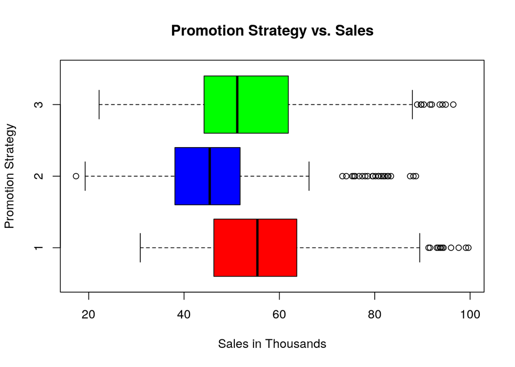

```r
boxplot(df$sales_in_thousands ~ df$promotion, data=df,
        main="Promotion Strategy vs. Sales", ylab="Promotion Strategy",
        xlab="Sales in Thousands", horizontal=TRUE,
        col=c("red","blue","green"))
```

Finally, let us test whether the difference between promotion strategies 1, 2, and 3 are statistically significant or not. Create three separate numeric vectors for sales (in thousands) corresponding to promotions 1, 2, and 3. Find the mean, standard deviation, and number of samples in each of these three vectors. Finally, we are ready to apply a two-sample t-test. In particular, we will use the most general case assuming variances are unknown and not necessarily equal:

$$H_0: \mu_1 - \mu_2 = 0$$

$$H_1: \mu_1 - \mu_2 \neq 0$$

$$t_0^{*} = \dfrac{\overline{X}_1 - \overline{X}_2}{\sqrt{\dfrac{S_1^2}{n_1}+\dfrac{S_2^2}{n_2}}}$$
where $t_0^{*}$ is $t$-distributed with degrees of freedom, $v$, given by:

$$v = \dfrac{\left( \dfrac{S_1^2}{n_1}+\dfrac{S_2^2}{n_2} \right)^2}{\dfrac{(S_1^2/n_1)^2}{n_1-1}+\dfrac{(S_2^2/n_2)^2}{n_2-1}}$$
**Promotion 1 vs. Promotion 2**.

Evaluate $t_0^{*}$ and then compute the p-value using `pt()`. For comparison, re-compute the p-value using the function `t.test()` which takes two vectors as input and automatically applies the two-sample $t$-test described above. Are the two p-values similar? Can we reject the null hypothesis or not?

**Promotion 1 vs. Promotion 3**.

Repeat the previous procedure for promotion 1 vs. promotion 3. What can you conclude?

**Promotion 2 vs. Promotion 3**.

Repeat the previous procedure for promotion 2 vs. promotion 3. What can you conclude?

How would you advise the company to proceed, i.e. with which marketing campaign(s) ?

## ANOVA

ANOVA can tell us whether there is a significant difference between treatment means overall, and when there is more than one factor present (e.g. two-way ANOVA, three-way ANOVA, etc.) we can find out whether the effect of the different factors (e.g. promotion, location, store age) and their iteractions are significant or not.

Let us run a one-way ANOVA and Tukey’s pair-wise comparison test. We first need to set up a data frame of the sales figures along with their promotion IDs which will be a factor (with 3 levels in this case). Then, we can call `anova()` as shown below. What can you conclude from the result of ANOVA? Is there a significant difference among the treatment means?

```
data <- data.frame(y = df$sales_in_thousands, f = factor(df$promotion))
m <- lm(y~f,data);
anova(m)
```

## Tukey’s pairwise test

To identify which pairs of treatments among the 3 have a significant difference in mean, we may apply Tukey’s HSD test as shown below. What can you conclude from the pairwise comparisons?

```
m <- aov(y~f,data)
cm <- TukeyHSD(m)
cm
```